# Sampler Comparisons

```r
library(extraDistr)
library(knitr)
library(kableExtra)
library(proftools)
library(tidyverse)
library(gridExtra)
```

# 1 Intro

# 2 Samplers

Here we will compare three samplers:

## 2.1 Importance Sampling

```r
importanceSampler <- function(x, N, samples = 1000, saturation = 10, nEff = length(sample),
                              alpha = 0.5, cutoff = 0.5) {
  n <- length(x)
  nLow <- sum(x < cutoff)

  priorDrawsRaw <- rdirichlet(samples * saturation, (nEff + alpha) / (N + 1) * rep(1, N + 1))
  priorDraws <- t(apply(matrix(priorDrawsRaw, nrow = samples * saturation)
                        [, -(N + 1), drop = FALSE], 1, cumsum))
  NLow <- apply(priorDraws, 1, function(x) sum(x < cutoff))
  weights <- dhyper(nLow, NLow, N - NLow, n)

  draws <- sample(1:(samples * saturation), size = samples, replace = TRUE, prob = weights)

  return(priorDraws[draws, ])
}
```

## 2.2 Block Sampling MCMC

Let $x_1, x_2, \dots, x_N$ represent the *ordered* population of size *N*. We denote $s_1 = x_1$, $s_2 = x_2 - x_1, \dots, s_{N-1} = x_N - x_{N-1}$, $s_N = 1 - x_N$ as the spacing of the ordered population.

From our formulation of the posterior, $\sum s_i = 1$ and $(s_1, \dots, s_{N+1}) \sim Dir(\frac{N_E + \alpha}{N+1}, \dots, \frac{N_E + \alpha}{N+1})$. We can use this to figure out the conditional prior for a set of spacings $s_{(m)}$.

For example, suppose we want the distribution of $x_{(1)} | x_{(2)}$, where $x_{(1)}, x_{(2)}$ partition $x$. Fortunately, this is relatively straightforward, and we end up with

$$\frac{1}{1 - \mathbf{1}^Tx_{(2)}} X_{(1)} | X_{(2)} = x_{(2)} \sim Dir(\frac{N_E + \alpha}{N+1}, \dots, \frac{N_E + \alpha}{N+1})$$

Essentially, nothing changes except we now know the spacings have to add up to $1 - \mathbf{1}^Tx_{(2)}$. We can use this to our advantage, using this conditional prior as our proposal. For simplicity, we let $N_E\ |\ N$, and consider proposal chunks of size $N / N_E$.

```r
mcmcPriorBlock <- function(x, N, samples = 1000, nEff = length(sample), alpha = 0.5, cutoff = 0.5) {

  lpost <- function(nLow, pop, diffs, N, nEff, alpha, cutoff) {
    NLow <- sum(pop < cutoff)
    lprior <- ddirichlet(diffs, (nEff + alpha) / (N + 1) * rep(1, N + 1), log = TRUE)
    llik <- dhyper(nLow, NLow, N - NLow, n, log = TRUE)
    return(llik + lprior)
  }

  priorProposal <- function(x) {
    as.numeric(rdirichlet(1, rep((nEff + alpha) / (N + 1), length(x))) * sum(x))
  }

  priorDensity <- function(x) {
    ddirichlet(x / sum(x), rep((nEff + alpha) / (N + 1), length(x)), log = TRUE)
  }

  spacings <- matrix(NA, nrow = samples, ncol = N + 1)
  data <- matrix(NA, nrow = samples, ncol = N)

  chunks <- split(1:(N + 1), cut(seq_along(1:(N + 1)), nEff * 2, labels = FALSE))

  chunks2 <- list()
  for(i in 1:(length(chunks) - 1)) {
    chunks2[[i]] <- c(chunks[[i]], chunks[[i + 1]])
  }


  n <- length(x)
  nLow <- sum(x < cutoff)

  data[1, ] <- sort(c(runif(ceiling(N * nLow / n), 0, cutoff),
                      runif(floor(N * (n - nLow) / n), cutoff, 1)))
  spacings[1, ] <- diff(c(0, data[1, ], 1))


  lp0 <- lpost(nLow, data[1, ], spacings[1, ], N, nEff, alpha, cutoff)

  for(i in 2:samples) {
    currentSpacings <- spacings[i - 1,]
    currentData <- data[i - 1, ]
    for(k in 1:length(chunks2)) {
      proposeSpacings <- currentSpacings
      proposeSpacings[chunks2[[k]]] <- priorProposal(proposeSpacings[chunks2[[k]]])
      proposeData <- cumsum(proposeSpacings)[-(N + 1)]
      lp1 <- lpost(nLow, proposeData, proposeSpacings, N, nEff, alpha, cutoff)

      u <- runif(1)
      if(is.finite(lp1) && log(u) < (lp1 - priorDensity(proposeSpacings)) -
         (lp0 - priorDensity(currentSpacings))) {
        currentSpacings <- proposeSpacings
        currentData <- proposeData
        lp0 <- lp1
      }
    }
    spacings[i, ] <- currentSpacings
    data[i, ] <- currentData
  }

  out <- list(
    data = data,
    spacings = spacings,
    x = x,
    N = n,
    samples = samples,
    nEff = nEff,
    alpha = alpha,
    cutoff = cutoff
  )

  return(out)
}
```

## 2.3 MCMC

```r
mcmcPrior <- function(x, N, samples = 1000, nEff = length(sample), alpha = 0.5, cutoff = 0.5) {

  lpost <- function(nLow, pop, diffs, N, nEff, alpha, cutoff) {
    NLow <- sum(pop < cutoff)
    lprior <- ddirichlet(diffs, (nEff + alpha) / (N + 1) * rep(1, N + 1), log = TRUE)
    llik <- dhyper(nLow, NLow, N - NLow, n, log = TRUE)
    return(llik + lprior)
  }

  priorProposal <- function(x) {
    as.numeric(rdirichlet(1, rep((nEff + alpha) / (N + 1), length(x))) * sum(x))
  }

  priorDensity <- function(x) {
    ddirichlet(x / sum(x), rep((nEff + alpha) / (N + 1), length(x)), log = TRUE)
  }

  spacings <- matrix(NA, nrow = samples, ncol = N + 1)
  data <- matrix(NA, nrow = samples, ncol = N)

  chunks <- split(1:(N + 1), 1:(N + 1))

  chunks2 <- list()
  for(i in 1:(length(chunks) - 1)) {
    chunks2[[i]] <- c(chunks[[i]], chunks[[i + 1]])
  }


  n <- length(x)
  nLow <- sum(x < cutoff)

  data[1, ] <- sort(c(runif(ceiling(N * nLow / n), 0, cutoff),
                      runif(floor(N * (n - nLow) / n), cutoff, 1)))
  spacings[1, ] <- diff(c(0, data[1, ], 1))


  lp0 <- lpost(nLow, data[1, ], spacings[1, ], N, nEff, alpha, cutoff)

  for(i in 2:samples) {
    currentSpacings <- spacings[i - 1,]
    currentData <- data[i - 1, ]
    for(k in 1:length(chunks2)) {
      proposeSpacings <- currentSpacings
      proposeSpacings[chunks2[[k]]] <- priorProposal(proposeSpacings[chunks2[[k]]])
      proposeData <- cumsum(proposeSpacings)[-(N + 1)]
      lp1 <- lpost(nLow, proposeData, proposeSpacings, N, nEff, alpha, cutoff)

      u <- runif(1)
      if(is.finite(lp1) && log(u) < (lp1 - priorDensity(proposeSpacings)) -
         (lp0 - priorDensity(currentSpacings))) {
        currentSpacings <- proposeSpacings
        currentData <- proposeData
        lp0 <- lp1
      }
    }
    spacings[i, ] <- currentSpacings
    data[i, ] <- currentData
  }

  out <- list(
    data = data,
    spacings = spacings,
    x = x,
    N = n,
    samples = samples,
    nEff = nEff,
    alpha = alpha,
    cutoff = cutoff
  )

  return(out)
}
```

# 3 Comparisons

```r
x1 <- c(0.11, 0.19, 0.27, 0.39, 0.42, 0.48, 0.59, 0.71, 0.84, 0.92)
x2 <- c(0.07, 0.12, 0.19, 0.26, 0.31, 0.36, 0.41, 0.49, 0.67, 0.89)
```

```r
N <- 39
nEff <- 4
alpha <- 0.5
cutoff <- 0.5
```

## 3.1 Location

### 3.1.1 Means

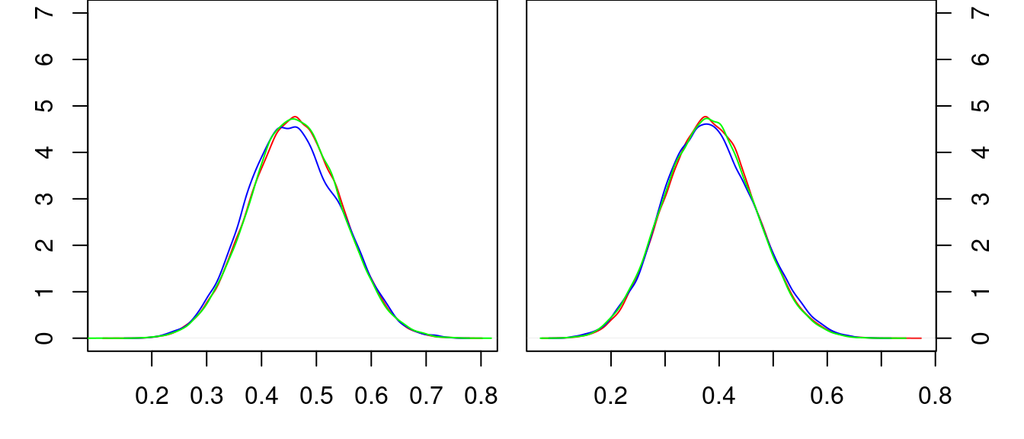

Figure 3.1: Density Comparison of Importance Sampling (red), Prior Proposal MCMC (blue), and Prior Proposal Block MCMC (green) on a 60%/40% sample (left) and 80%/20% sample (right)

### 3.1.2 Medians

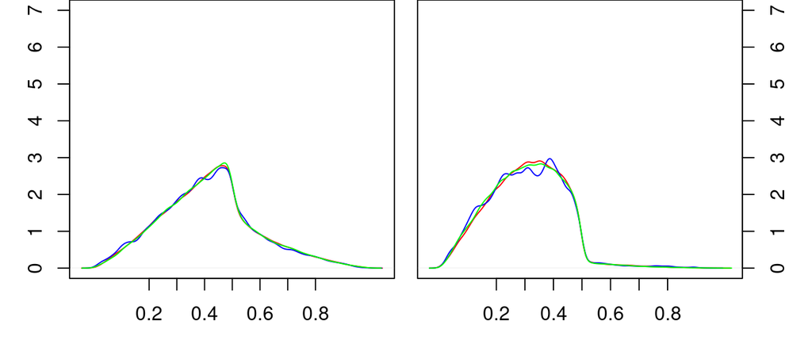

Figure 3.2: Density Comparison of Importance Sampling (red), Prior Proposal MCMC (blue), and Prior Proposal Block MCMC (green) on a 60%/40% sample (left) and 80%/20% sample (right)

### 3.1.3 Empirical CDFs

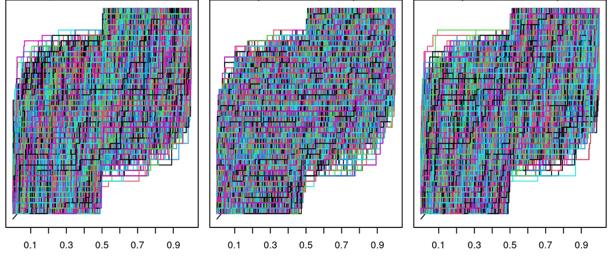

Figure 3.3: CDFs of Importance Sampling (left), Proposal MCMC (center), and Prior Proposal Block MCMC (right) for 60%/40% sample

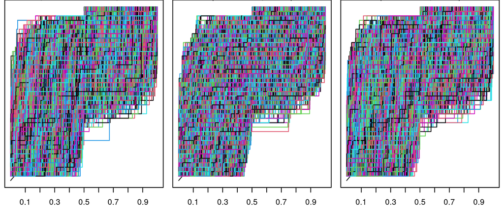

Figure 3.4: CDFs of Importance Sampling (left), Proposal MCMC (center), and Prior Proposal Block MCMC (right) for 80%/20% sample

### 3.1.4 F(0.5)

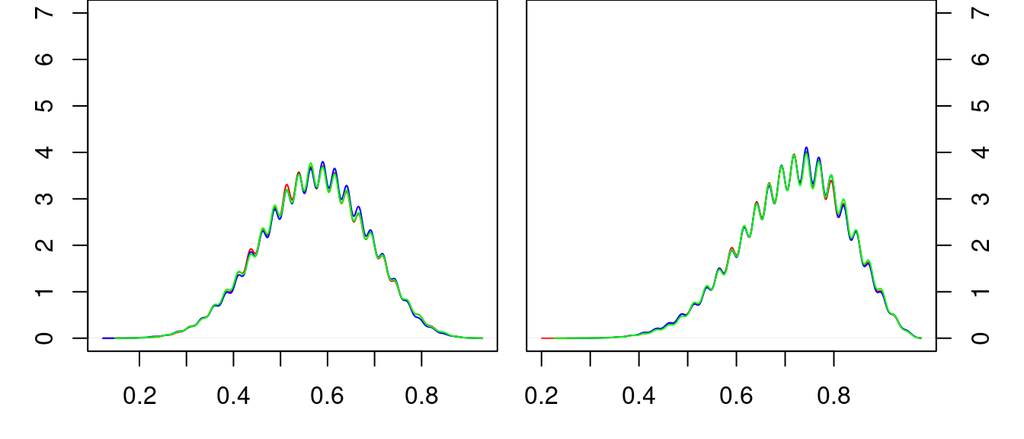

(#fig:cdf0.5)F(0.5) Comparison of Importance Sampling (red), Prior Proposal MCMC (blue), and Prior Proposal Block MCMC (green) on a 60%/40% sample (left) and 80%/20% sample (right)

### 3.1.5 F(0.25)

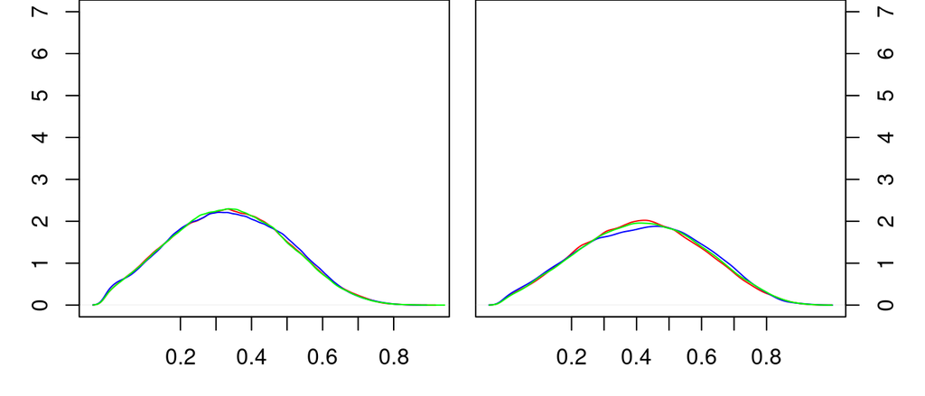

(#fig:cdfs0.25)F(0.25) Comparison of Importance Sampling (red), Prior Proposal MCMC (blue), and Prior Proposal Block MCMC (green) on a 60%/40% sample (left) and 80%/20% sample (right)

## 3.2 Time

Table 3.1: Profile for Importance Sampling (left), Prior Proposal MCMC (center), and Prior Proposal Blocked MCMC (right)

|  | Total % | Total Time | Self % | Self Time |
| --- | --- | --- | --- | --- |
| importanceSampler | 100.00 | 5.72 | 0.70 | 0.04 |
| apply | 64.69 | 3.70 | 39.86 | 2.28 |
| t | 42.66 | 2.44 | 0.00 | 0.00 |
| cpp_rdirichlet | 27.27 | 1.56 | 27.27 | 1.56 |
| rdirichlet | 27.27 | 1.56 | 0.00 | 0.00 |
| FUN | 8.39 | 0.48 | 6.64 | 0.38 |
| aperm | 5.59 | 0.32 | 0.00 | 0.00 |
| aperm.default | 5.59 | 0.32 | 5.59 | 0.32 |
| array | 4.90 | 0.28 | 4.90 | 0.28 |
| t.default | 4.90 | 0.28 | 4.90 | 0.28 |

|  | Total % | Total Time | Self % | Self Time |
| --- | --- | --- | --- | --- |
| mcmcPrior | 100.00 | 134.44 | 8.02 | 10.78 |
| ddirichlet | 66.44 | 89.32 | 20.22 | 27.18 |
| priorDensity | 47.60 | 64.00 | 2.07 | 2.78 |
| cpp_ddirichlet | 28.27 | 38.00 | 28.27 | 38.00 |
| lpost | 27.61 | 37.12 | 4.09 | 5.50 |
| matrix | 14.62 | 19.66 | 14.19 | 19.08 |
| priorProposal | 13.98 | 18.80 | 1.98 | 2.66 |
| rdirichlet | 11.56 | 15.54 | 5.04 | 6.78 |
| is.data.frame | 4.82 | 6.48 | 3.82 | 5.14 |
| cpp_rdirichlet | 4.21 | 5.66 | 4.21 | 5.66 |

|  | Total % | Total Time | Self % | Self Time |
| --- | --- | --- | --- | --- |
| mcmcPriorBlock | 100.00 | 25.26 | 9.11 | 2.30 |
| ddirichlet | 65.72 | 16.60 | 19.71 | 4.98 |
| priorDensity | 46.00 | 11.62 | 2.14 | 0.54 |
| cpp_ddirichlet | 28.03 | 7.08 | 28.03 | 7.08 |
| lpost | 27.47 | 6.94 | 3.40 | 0.86 |
| priorProposal | 15.12 | 3.82 | 1.66 | 0.42 |
| matrix | 14.57 | 3.68 | 13.94 | 3.52 |
| rdirichlet | 13.30 | 3.36 | 5.15 | 1.30 |
| cpp_rdirichlet | 5.94 | 1.50 | 5.94 | 1.50 |
| is.data.frame | 4.67 | 1.18 | 3.56 | 0.90 |

# 4 Characteristics

## 4.1 CDF

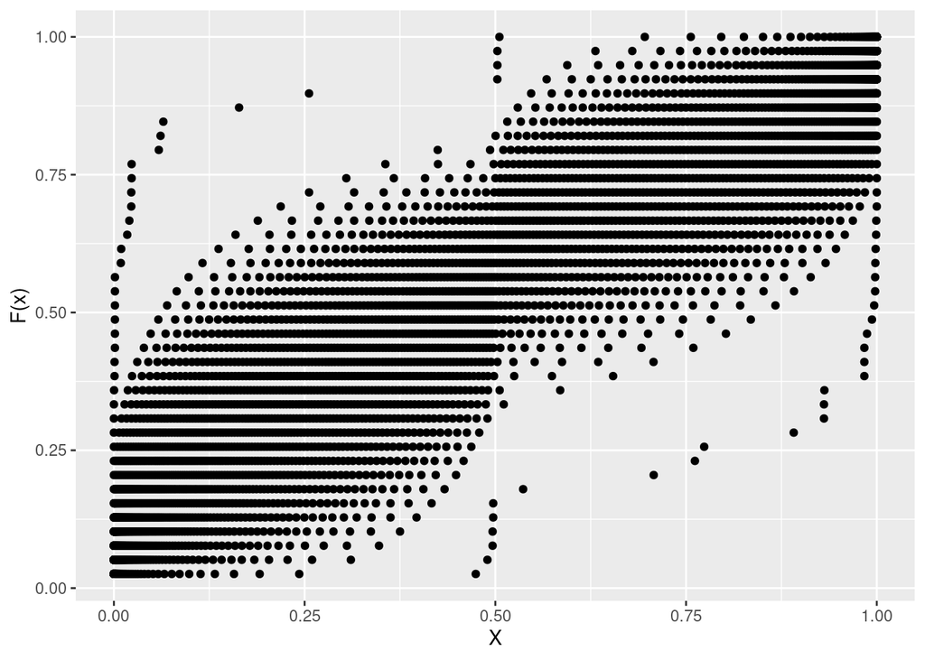

## 4.2 Medians

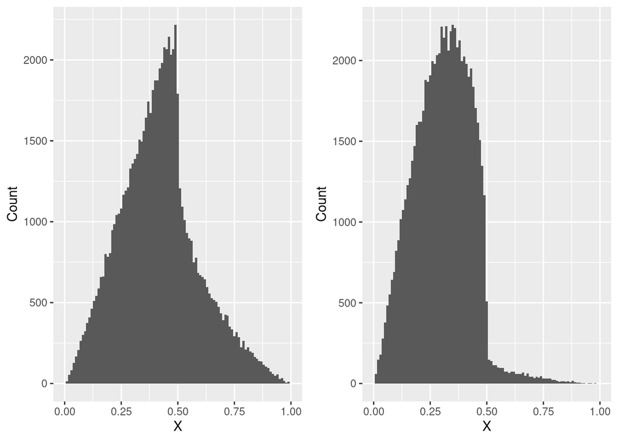

## 4.3 F(0.5)

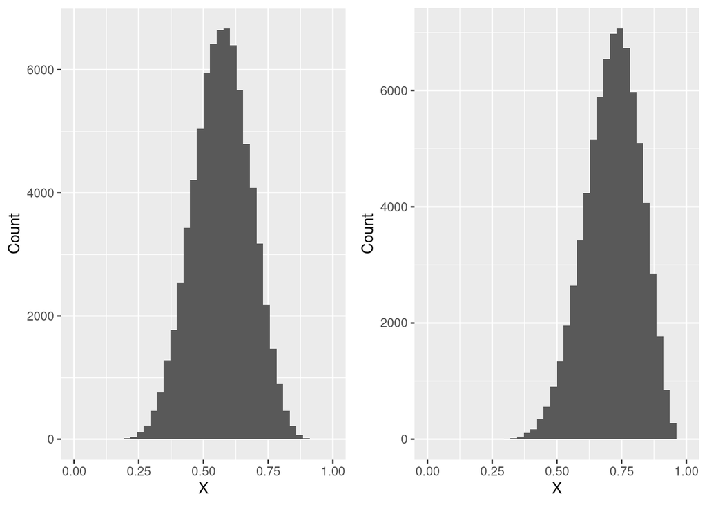

# 5 Changing the Cutoff

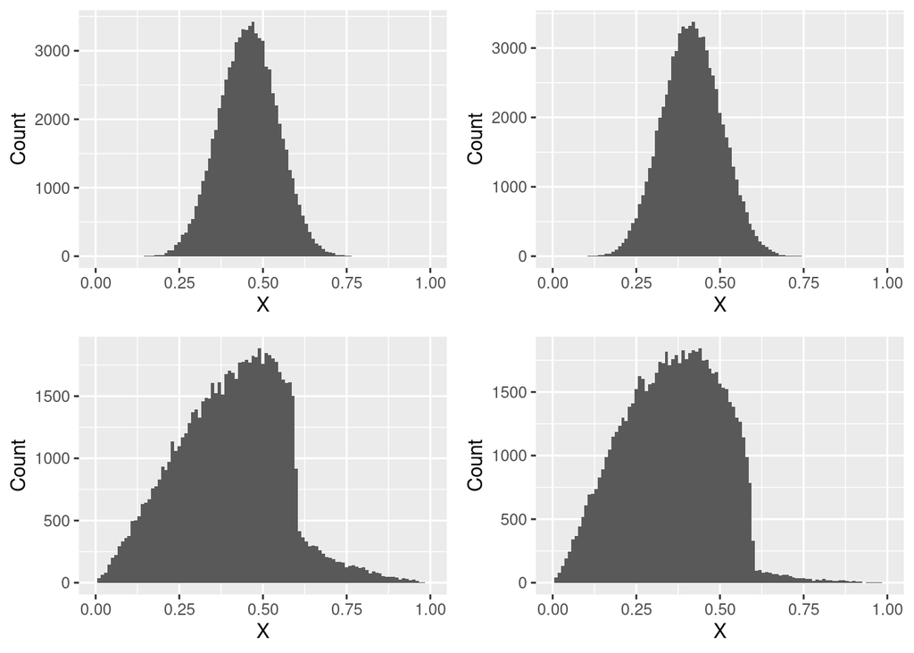

```r
g1 <- data.frame(X = apply(pops1_1_2, 1, mean)) %>%
  ggplot(mapping = aes(x = X)) +
  geom_histogram(binwidth = 0.01) +
  lims(x = c(0, 1)) +
  labs(y = "Count")

g2 <- data.frame(X = apply(pops2_1_2, 1, mean)) %>%
  ggplot(mapping = aes(x = X)) +
  geom_histogram(binwidth = 0.01) +
  lims(x = c(0, 1)) +
  labs(y = "Count")

g3 <- data.frame(X = apply(pops1_1_2, 1, median)) %>%
  ggplot(mapping = aes(x = X)) +
  geom_histogram(binwidth = 0.01) +
  lims(x = c(0, 1)) +
  labs(y = "Count")

g4 <- data.frame(X = apply(pops2_1_2, 1, median)) %>%
  ggplot(mapping = aes(x = X)) +
  geom_histogram(binwidth = 0.01) +
  lims(x = c(0, 1)) +
  labs(y = "Count")

grid.arrange(g1, g2, g3, g4, nrow = 2, ncol = 2)



```

# 6 Diagnostics

## 6.1 Trace Plots (Mean)

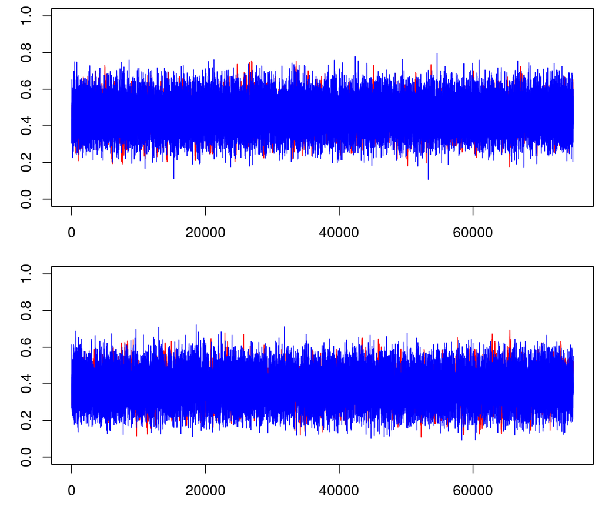

Figure 6.1: Trace Plots for the Mean, from Prior Proposal MCMC (red), and Prior Proposal Block MCMC (blue) on a 60%/40% sample (top) and 80%/20% sample (bottom)

## 6.2 Trace Plots (Median)

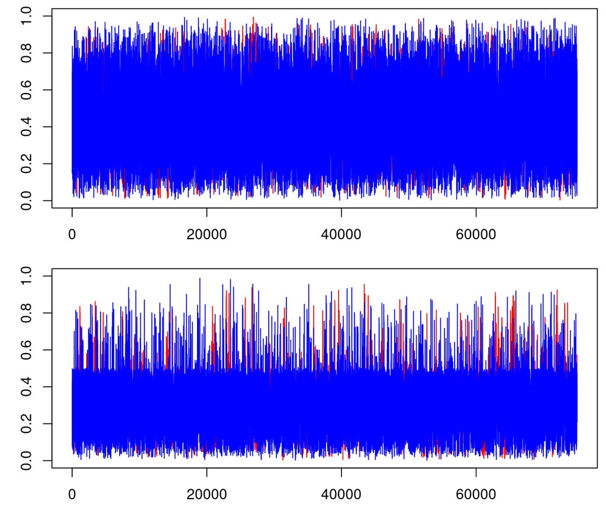

Figure 6.2: Trace Plots for the Median, from Prior Proposal MCMC (red), and Prior Proposal Block MCMC (blue) on a 60%/40% sample (top) and 80%/20% sample (bottom)

# 7 Converting to Normal

Lets first create a new sample. We will use the same values from the previous examples for $N$, $nEff$, $\alpha$, and the cutoff.

For now, we will only use the importance sampler.

```r
x3 <- sort(rnorm(10, mean = pi, sd = 1))
x3
```

```
#>  [1] 0.6598865 1.6863729 2.1761706 3.2444545 3.3057437 3.5020959 3.5114828
#>  [8] 3.5705192 3.8063235 3.8577208
```

Now we can convert them to $[0, 1]$ using the CDF.

```r
x3Unif <- pnorm(x3, mean = mean(x3), sd = sd(x3))
x3Unif
```

```
#>  [1] 0.01646093 0.12111852 0.23897224 0.61533315 0.63712412 0.70371283
#>  [7] 0.70675217 0.72552759 0.79409287 0.80756403
```

```r
sum(x3Unif < 0.5)
```

```
#> [1] 3
```

```r
unifPops <- importanceSampler(x = x3Unif, N = N, samples = samples, nEff = 4)
normPops <- t(apply(unifPops, 1, qnorm, mean = mean(x3), sd = sd(x3)))
normPopsFinite <- normPops[complete.cases(normPops), ]
```

And now we can plot the distribution of the means and CDFs.

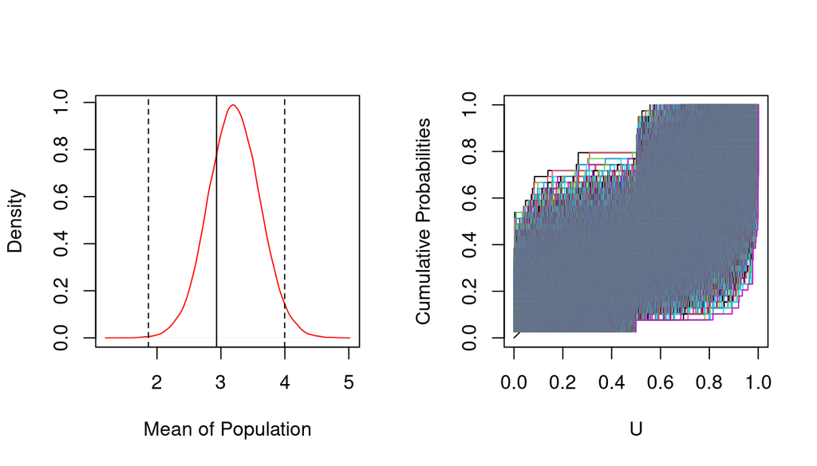